# Exploring Auto data using Seaborn and Stats(SciPy)

### Author: Lakshmi Krishna

#### July 2019

```python
import pandas as pd
import matplotlib.pyplot as plt
import seaborn as sn
from scipy import stats
```

```python
auto_df=pd.read_csv("auto.csv")
```

## Graph cheat sheet

#### Univariate Data

| Numerical (Continuous) | Categorical/Discrete(Num) |
| --- | --- |
| Histogram | Bar chart |
| Distribution | Cat Plot |
| Box Plot | - |

#### Bivariate Data

| Categorical/Categorical/Discrete | Categorical/Numerical | Numerical/Numerical |
| --- | --- | --- |
| Bar charts | Box Plots by category | Scatter plots |
| - | Overlapping Distribution Plots | Line charts |

#### Multivariate Data

| All numeric | Numeric/Categorical |
| --- | --- |
| Pair plots | Facet wrapped plots |
| Heatmaps | - |

## Explore data

```python
auto_df.shape
```

```
(397, 9)
```

*There are 397 rows and 9 features*

```python
auto_df.info()
```

```
<class 'pandas.core.frame.DataFrame'>
RangeIndex: 397 entries, 0 to 396
Data columns (total 9 columns):
mpg             397 non-null float64
cylinders       397 non-null int64
displacement    397 non-null float64
horsepower      397 non-null object
weight          397 non-null int64
acceleration    397 non-null float64
year            397 non-null int64
origin          397 non-null int64
name            397 non-null object
dtypes: float64(3), int64(4), object(2)
memory usage: 28.0+ KB
```

```python
auto_df.head(10)
```

|  | mpg | cylinders | displacement | horsepower | weight | acceleration | year | origin | name |
| --- | --- | --- | --- | --- | --- | --- | --- | --- | --- |
| 0 | 18.0 | 8 | 307.0 | 130 | 3504 | 12.0 | 70 | 1 | chevrolet chevelle malibu |
| 1 | 15.0 | 8 | 350.0 | 165 | 3693 | 11.5 | 70 | 1 | buick skylark 320 |
| 2 | 18.0 | 8 | 318.0 | 150 | 3436 | 11.0 | 70 | 1 | plymouth satellite |
| 3 | 16.0 | 8 | 304.0 | 150 | 3433 | 12.0 | 70 | 1 | amc rebel sst |
| 4 | 17.0 | 8 | 302.0 | 140 | 3449 | 10.5 | 70 | 1 | ford torino |
| 5 | 15.0 | 8 | 429.0 | 198 | 4341 | 10.0 | 70 | 1 | ford galaxie 500 |
| 6 | 14.0 | 8 | 454.0 | 220 | 4354 | 9.0 | 70 | 1 | chevrolet impala |
| 7 | 14.0 | 8 | 440.0 | 215 | 4312 | 8.5 | 70 | 1 | plymouth fury iii |
| 8 | 14.0 | 8 | 455.0 | 225 | 4425 | 10.0 | 70 | 1 | pontiac catalina |
| 9 | 15.0 | 8 | 390.0 | 190 | 3850 | 8.5 | 70 | 1 | amc ambassador dpl |

**Convert Horsepower to numeric instead of object**

```python
auto_df[-auto_df.horsepower.str.isnumeric()]
```

|  | mpg | cylinders | displacement | horsepower | weight | acceleration | year | origin | name |
| --- | --- | --- | --- | --- | --- | --- | --- | --- | --- |
| 32 | 25.0 | 4 | 98.0 | ? | 2046 | 19.0 | 71 | 1 | ford pinto |
| 126 | 21.0 | 6 | 200.0 | ? | 2875 | 17.0 | 74 | 1 | ford maverick |
| 330 | 40.9 | 4 | 85.0 | ? | 1835 | 17.3 | 80 | 2 | renault lecar deluxe |
| 336 | 23.6 | 4 | 140.0 | ? | 2905 | 14.3 | 80 | 1 | ford mustang cobra |
| 354 | 34.5 | 4 | 100.0 | ? | 2320 | 15.8 | 81 | 2 | renault 18i |

```python
auto_df['horsepower']=pd.to_numeric(auto_df['horsepower'], errors='coerce')
```

```python
auto_df.info()
```

```
<class 'pandas.core.frame.DataFrame'>
RangeIndex: 397 entries, 0 to 396
Data columns (total 9 columns):
mpg             397 non-null float64
cylinders       397 non-null int64
displacement    397 non-null float64
horsepower      392 non-null float64
weight          397 non-null int64
acceleration    397 non-null float64
year            397 non-null int64
origin          397 non-null int64
name            397 non-null object
dtypes: float64(4), int64(4), object(1)
memory usage: 28.0+ KB
```

```python
auto_df[auto_df.horsepower.isnull()]
```

|  | mpg | cylinders | displacement | horsepower | weight | acceleration | year | origin | name |
| --- | --- | --- | --- | --- | --- | --- | --- | --- | --- |
| 32 | 25.0 | 4 | 98.0 | NaN | 2046 | 19.0 | 71 | 1 | ford pinto |
| 126 | 21.0 | 6 | 200.0 | NaN | 2875 | 17.0 | 74 | 1 | ford maverick |
| 330 | 40.9 | 4 | 85.0 | NaN | 1835 | 17.3 | 80 | 2 | renault lecar deluxe |
| 336 | 23.6 | 4 | 140.0 | NaN | 2905 | 14.3 | 80 | 1 | ford mustang cobra |
| 354 | 34.5 | 4 | 100.0 | NaN | 2320 | 15.8 | 81 | 2 | renault 18i |

**Which years are the cars manufactured in?**

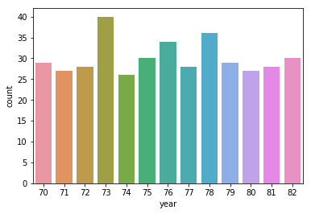

```python
sn.countplot(x="year", data=auto_df);
```

**Which countries do the cars belong to?**

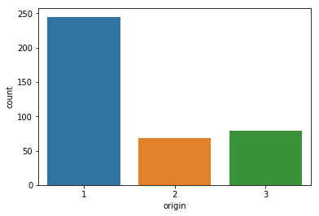

```python
sn.countplot(x="origin", data=auto_df);
```

*Note that the cars belong to 3 countries 1- USA 2-Europe 3- Japan*

### Who makes cars with higher fuel efficiency

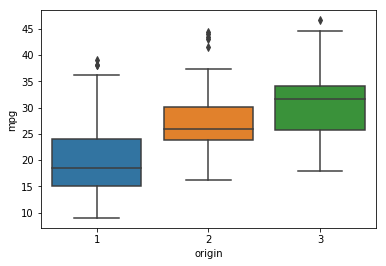

```python
sn.boxplot(data=auto_df, x= 'origin',y='mpg');
```

*We are aware that Japanese make more fuel efficient cars than Americans do. Let us see if this is true.*

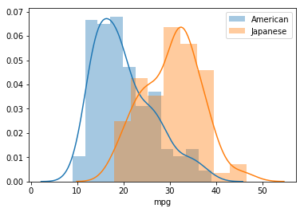

```python
sn.distplot(auto_df[auto_df.origin==1]['mpg'],label="American");
sn.distplot(auto_df[auto_df.origin==3]['mpg'],label="Japanese");
plt.legend();
```

**Two-sample t-test for hypothesis testing**

```python
stats.ttest_ind(auto_df[auto_df.origin==1]['mpg'],auto_df[auto_df.origin==3]['mpg'])
```

```
Ttest_indResult(statistic=-12.67722648020723, pvalue=3.370227003938695e-30)
```

*Based on the above t-test we can conclude at 0.05 significance level, that the null hypothesis is rejected.(p-value <0.05). Japanese cars are more fuel efficicent than American make cars.*

**Which car has the highest and the least fuel efficiecy?**

```python
    print(auto_df[['origin', 'name','mpg']][auto_df.mpg == auto_df.mpg.max()])
```

```
     origin       name   mpg
322       3  mazda glc  46.6
```

```python
print(auto_df[['origin', 'name','mpg']][auto_df.mpg == auto_df.mpg.min()])
```

```
    origin      name  mpg
28       1  hi 1200d  9.0
```

### Who makes cars with higher horsepower?

```python
auto_df=auto_df.dropna()
```

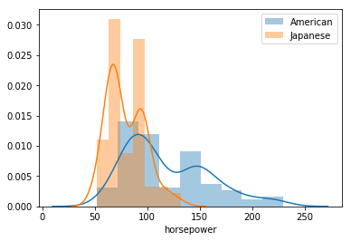

```python
sn.distplot(auto_df[auto_df.origin==1]['horsepower'],label="American");
sn.distplot(auto_df[auto_df.origin==3]['horsepower'],label="Japanese");
plt.legend();
```

*We can see that majority of the American cars have higher Horsepower compared to Japanese make*

**Let us conduct a 2-sample t-test to see if the above hypothesis holds good.**`

```python
stats.ttest_ind(auto_df[auto_df.origin==1]['horsepower'],auto_df[auto_df.origin==3]['horsepower'])
```

```
Ttest_indResult(statistic=8.460994146188728, pvalue=9.438939723740944e-16)
```

*Based on the above t-test, we can conclude at the 0.05 significance level , that the null hypothesis is rejected(p-value<0.05).American make cars in the dataset, have a higher horsepower than Japanese cars*

**Which cars have the highest and least horsepower?**

```python
print(auto_df[['origin', 'name','horsepower']][auto_df.horsepower == auto_df.horsepower.max()])
```

```
     origin                name  horsepower
116       1  pontiac grand prix       230.0
```

```python
print(auto_df[['origin', 'name','horsepower']][auto_df.horsepower == auto_df.horsepower.min()])
```

```
     origin                          name  horsepower
19        2  volkswagen 1131 deluxe sedan        46.0
102       2       volkswagen super beetle        46.0
```

### Exploring plots in Seaborn

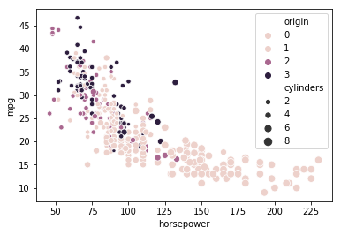

```python
sn.scatterplot(data= auto_df,x=auto_df.horsepower, y=auto_df.mpg,
               hue=auto_df.origin,size=auto_df.cylinders);
```

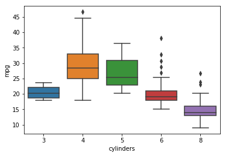

```python
sn.boxplot(data=auto_df,x=auto_df.cylinders, y=auto_df.mpg);
```

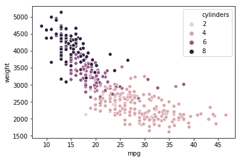

```python
sn.scatterplot(data= auto_df,x=auto_df.mpg, y=auto_df.weight,
               hue=auto_df.cylinders);
```

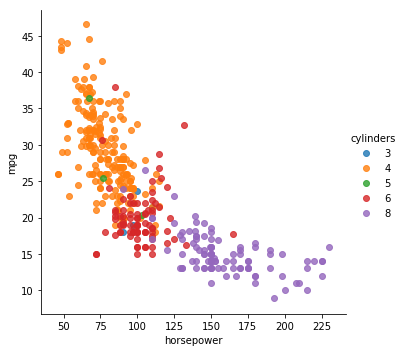

```python
sn.lmplot(data=auto_df, x='horsepower', y='mpg',hue='cylinders',fit_reg=False);
```

#### Heat map

```python
corr_mat=auto_df[['mpg','horsepower','acceleration','displacement','weight']].corr()
```

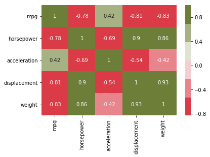

```python
sn.heatmap(corr_mat,annot=True, cmap=sn.diverging_palette(10,100));
```

#### Pair Plots

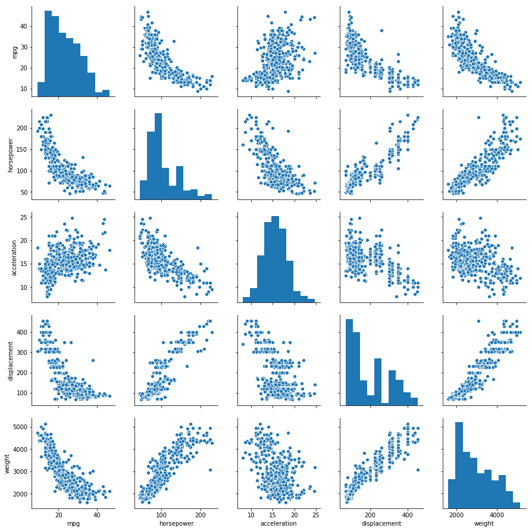

```python
sn.pairplot(auto_df[['mpg','horsepower','acceleration','displacement','weight']]);
```

#### Violin Plots

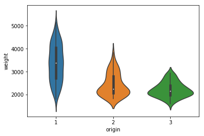

```python
sn.violinplot(data=auto_df, y='weight',x='origin');
```

#### Swarm plots

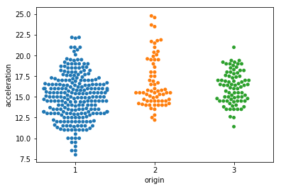

```python
g=sn.swarmplot(data=auto_df, y='acceleration',x='origin');
```

#### Faceting with plots

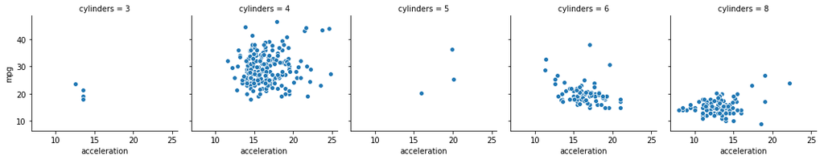

```python
g = sn.FacetGrid(auto_df, col='cylinders', margin_titles=True);
g.map(sn.scatterplot, "acceleration", "mpg");
```